# Chap 8.1

Mijeong Kim

```r
library(tsibble)
library(tsibbledata)
library(tibble)
library(dplyr)
library(knitr)
library(ggplot2)
library(fpp3)
library(fpp2)
library(seasonal)
library(feasts)
```

# 8. Exponential smoothing (지수 평활법)

- 1950년대 후반에 제안된 예측 기법
- 과거 관측값에 지수적으로 감소하는 가중치를 부여하여 가중평균을 계산하는 방법
- 최근 관측값일수록 더 높은 가중치를 가지며, 다양한 시계열에 대해 신뢰성 높은 예측을 빠르게 수행할 수 있어 산업 분야에서 매우 유용함.
1. 8.1–8.4절: 주요 지수 평활 기법과 다양한 시계열 특성에 따른 적용 방법을 설명
2. 8.5–8.7절: 지수 평활법에 대응하는 통계적 모델을 소개

## 8.1 Simple exponential smoothing (SES, 단순 지수평활)

- 뚜렷한 추세나 계절성이 없는 데이터를 예측할 때 적합
- 예를 들어, Figure 8.1에 제시된 데이터는 뚜렷한 추세나 계절적 패턴을 보이지 않음.

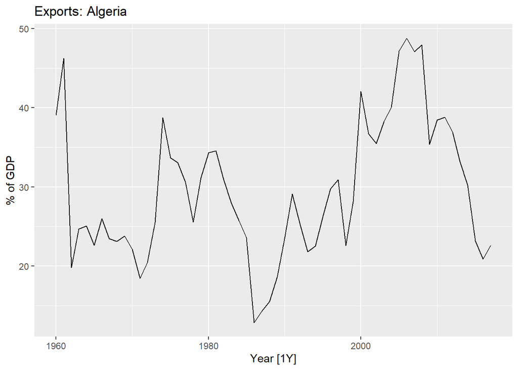

```r
algeria_economy <- global_economy |>
  filter(Country == "Algeria")
algeria_economy |>
  autoplot(Exports) +
  labs(y = "% of GDP", title = "Exports: Algeria")
```

Figure 8.1: Exports of goods and services from Algeria from 1960 to 2017.

- **Naïve Method(단순 기법)**: 미래 예측값은 마지막 관측값과 같다.
  $$\hat{y}_{T+h|T} = y_T$$
- **평균법(Average Method)**: 미래 예측값은 전체 관측값의 평균이다.
  $$\hat{y}_{T+h|T} = \frac{1}{T}
  \sum_{t=1}^{T} y_t$$
  평균 기법에서는 모든 관측값이 똑같이 중요하고, 예측값을 생성할 때 이러한 관측값에 같은 가중치를 부여한다.

#### SES의 필요성

- Naïve Method은 가장 최근 값만 중요하게 보고, 평균법은 모든 값을 동일하게 중요하게 본다.
- 현실에서는 최근 관측값에 더 많은 가중치를 부여하는 것이 합리적일 수 있다.

#### 단순 지수 평활 (SES)

- 시간에 따라 과거 관측값의 가중치를 지수적으로 감소시키는 가중 평균을 사용한다.
- **식**:
  $$\hat{y}_{T+1|T} = \alpha y_T +
  \alpha(1-\alpha) y_{T-1} + \alpha(1-\alpha)^2 y_{T-2} + \cdots$$
- 여기서 $0 \leq \alpha \leq 1$ 은 평활 계수(smoothing parameter)이다.

#### $\alpha$ (Alpha) 값에 따른 가중치 변화 예시

| 관측값 | α=0.2 | α=0.4 | α=0.6 | α=0.8 |
| --- | --- | --- | --- | --- |
| $y_T$ | 0.2000 | 0.4000 | 0.6000 | 0.8000 |
| $y_{T-1}$ | 0.1600 | 0.2400 | 0.2400 | 0.1600 |
| $y_{T-2}$ | 0.1280 | 0.1440 | 0.0960 | 0.0320 |
| $y_{T-3}$ | 0.1024 | 0.0864 | 0.0384 | 0.0064 |
| $y_{T-4}$ | 0.0819 | 0.0518 | 0.0154 | 0.0013 |
| $y_{T-5}$ | 0.0655 | 0.0311 | 0.0061 | 0.0003 |

- $\alpha$가 클수록 최근 관측값에 더 큰 가중치를 부여한다.
- $\alpha$가 1이면 Naïve Method과 같아진다:
  $$\hat{y}_{T+1|T} = y_T$$

### Weighted average form (가중 평균 형태)

#### Simple Exponential Smoothing (SES)의 기본 수식

- 시간 $T+1$ 시점의 예측값은 최근 관측값 $y_T$와 직전 예측값 $\hat{y}_{T|T-1}$의 가중 평균이다.

$$\hat{y}_{T+1|T} = \alpha y_T + (1-\alpha) \hat{y}_{T|T-1}$$

- 여기서 $0 \leq \alpha \leq 1$은 평활 계수이다.

#### fitting 과정

- 학습 데이터에 대한 적합값(fitted values)도 다음과 같이 구한다.

$$\hat{y}_{t+1|t} = \alpha y_t + (1-\alpha) \hat{y}_{t|t-1}
\quad \text{for} \quad t=1,\ldots,T$$

- 초기값 설정이 필요하며, 초기 수준(level) 값은 $\ell_0$로 설정한다.

#### 적합값 전개

초기값을 기준으로 전개하면 다음과 같다:

- $\hat{y}_{2|1} = \alpha y_1 + (1-\alpha) \ell_0$
- $\hat{y}_{3|2} = \alpha y_2 + (1-\alpha) \hat{y}_{2|1}$
- $\hat{y}_{4|3} = \alpha y_3 + (1-\alpha) \hat{y}_{3|2}$
- ⋮
- $\hat{y}_{T|T-1} = \alpha y_{T-1} + (1-\alpha) \hat{y}_{T-1|T-2}$

이를 반복적으로 대입하면 다음과 같은 식이 얻어진다.

#### 일반화된 식

최종적으로, 시간 $T+1$의 예측값은 다음과 같이 표현된다.

$$\hat{y}_{T+1|T} = \sum_{j=0}^{T-1} \alpha (1-\alpha)^j y_{T-j} +
(1-\alpha)^T \ell_0$$

- 여기서, $(1-\alpha)^T \ell_0$ 항은 $T$가 클 경우 매우 작아져 무시할 수 있다.
- 결과적으로 이는 단순 지수 평활법의 가중 평균 형태(Equation 8.1)와 일치한다.

### Component Form (성분 형태)

- **단순 지수 평활(Simple Exponential Smoothing)**은 오직 **수준(Level)** 성분 $\ell_t$만 포함한다.
- 이후 다룰 다른 방법들은 추세(Trend) $b_t$와 계절성(Seasonality) $s_t$ 성분도 포함할 수 있다.

#### 구성 요소

- **Forecast Equation (예측 식)**:
  $$\hat{y}_{t+h|t} = \ell_t$$
- **Smoothing Equation (수준 평활 식)**:
  $$\ell_t = \alpha y_t + (1-\alpha) \ell_{t-1}$$
- 여기서
  - $\ell_t$는 시점 $t$에서의 수준(level)이다.
  - $\alpha$는 평활 계수이다.

#### 해석

- **Forecast Equation**은 예측값이 현재 수준 추정치 $\ell_t$임을 보여준다.
- **Smoothing Equation**은 매 시점마다 수준을 어떻게 업데이트할지를 설명한다.
- $h=1$이면 피팅값(fitted values), $t=T$이면 훈련 데이터 이후의 예측값을 얻는다.

#### 주의사항

- 수준 $\ell_t$를 $\hat{y}_{t+1|t}$로, $\ell_{t-1}$를 $\hat{y}_{t|t-1}$로 치환하면, 앞서 소개한 **가중 평균 형태(weighted average form)**의 식을 다시 얻을 수 있다.

$$\ell_t = \alpha y_t + (1-\alpha)\ell_{t-1}$$
$$\ell_{t-1} = \alpha y_{t-1} + (1-\alpha)\ell_{t-2}$$
$$\ell_t
= \alpha y_t + (1-\alpha)\bigl[\alpha y_{t-1} +
(1-\alpha)\ell_{t-2}\bigr]$$

따라서

$$\ell_t
= \alpha y_t + \alpha(1-\alpha)y_{t-1} + (1-\alpha)^2 \ell_{t-2}$$

같은 방식으로 $\ell_{t-2}, \ell_{t-3}, \dots$를 계속 대입하면

$$\ell_t
= \alpha y_t + \alpha(1-\alpha)y_{t-1} + \alpha(1-\alpha)^2 y_{t-2} +
\cdots$$

즉, $\ell_t$는 과거 관측값들의 지수적으로 감소하는 가중평균으로 표현된다.

$$\ell_t = \sum_{j=0}^{\infty} \alpha(1-\alpha)^j y_{t-j}$$

따라서 단순 지수평활은 최근 관측값에 더 큰 가중치를 두고, 과거로 갈수록 가중치를 지수적으로 감소시키는 방법으로 이해할 수 있다.

- 단순 지수 평활에서는 component form 자체가 크게 유용하지 않지만, 이후 **추세**나 **계절성**이 추가되는 경우 가장 간편한 표현 방식이 된다.

### Flat Forecasts (평평한 예측값)

- 단순 지수 평활(SES)에서는 예측 함수가 “평평(flat)”하다.
- 모든 미래 예측값은 마지막 수준(level) 값과 같다.

$$\hat{y}_{T+h|T} = \hat{y}_{T+1|T} = \ell_T \quad \text{for} \quad
h=2,3,\ldots$$

- 이 방법은 **추세나 계절성 없는 시계열**에만 적합하다.

### Optimisation (최적화)

#### 필요한 선택 사항

- 단순 지수 평활에서는 다음 두 가지를 선택해야 한다:
  - 평활 계수 $\alpha$
  - 초기 수준값 $\ell_0$
- 이 값들이 주어지면 모든 예측이 계산 가능하다.

#### 선택 방법

- 경험적으로 주관적으로 설정할 수도 있으나, 일반적으로 **관측 데이터를 이용하여** 추정하는 것이 더 신뢰할 수 있다.

#### SSE 최소화

- 추정은 **잔차 제곱합(Sum of Squared Errors, SSE)**을 최소화하는 방식으로 수행된다.
- 잔차(residual)는 다음과 같이 정의된다.

$$e_t = y_t - \hat{y}_{t|t-1}
\quad \text{for} \quad t=1,\ldots,T$$

- SSE는 다음과 같다.

$$\text{SSE} = \sum_{t=1}^T (y_t - \hat{y}_{t|t-1})^2 = \sum_{t=1}^T e_t^2$$

#### 최적화 방법

- 회귀분석처럼 해석적 해(closed-form solution)가 존재하지 않으며,
- **비선형 최적화 도구(non-linear optimization tool)**를 사용하여 최적값을 찾는다.

### Example: Algerian exports (알제리 수출 예제)

```r
# Estimate parameters
fit <- algeria_economy |>
  model(ETS(Exports ~ error("A") + trend("N") + season("N")))
fc <- fit |>
  forecast(h = 5)
```

#### 파라미터 추정

- 관측 구간: $t = 1, 2, \ldots, 58$
- 최적화 조건: $0 \leq \alpha \leq 1$
- 최소화 대상: SSE (Sum of Squared Errors)

추정된 파라미터:

- $\hat{\alpha} = 0.84$
- $\hat{\ell}_0 = 39.5$

#### 예측 결과 요약 (Table 8.1)

- 두 번째 마지막 열: 각 시점 $t = 0$부터 $t = 58$까지의 수준(Level) $\ell_t$ 값
- 마지막 열: $h = 1$부터 $5$까지 미래 예측값

| Year | Time $t$ | Observation $y_t$ | Level $\ell_t$ | Forecast $\hat{y}_{t\|t-1}$ |
| --- | --- | --- | --- | --- |
| 1959 | 0 |  | 39.54 |  |
| 1960 | 1 | 39.04 | 39.12 | 39.54 |
| 1961 | 2 | 46.24 | 45.10 | 39.12 |
| 1962 | 3 | 19.79 | 23.84 | 45.10 |
| 1963 | 4 | 24.68 | 24.55 | 23.84 |
| 1964 | 5 | 25.08 | 25.00 | 24.55 |
| … | … | … | … | … |
| 2016 | 57 | 20.86 | 21.43 | 24.39 |
| 2017 | 58 | 22.64 | 22.44 | 21.43 |

- 미래 예측:

| Year | Step $h$ | Forecast $\hat{y}_{T+h\|T}$ |
| --- | --- | --- |
| 2018 | 1 | 22.44 |
| 2019 | 2 | 22.44 |
| 2020 | 3 | 22.44 |
| 2021 | 4 | 22.44 |
| 2022 | 5 | 22.44 |

#### 시각화

- Figure 8.2의 검은 선은 실제 데이터를 나타낸다.
- 데이터는 시간이 지나면서 수준(Level)이 변동하는 모습을 보인다.

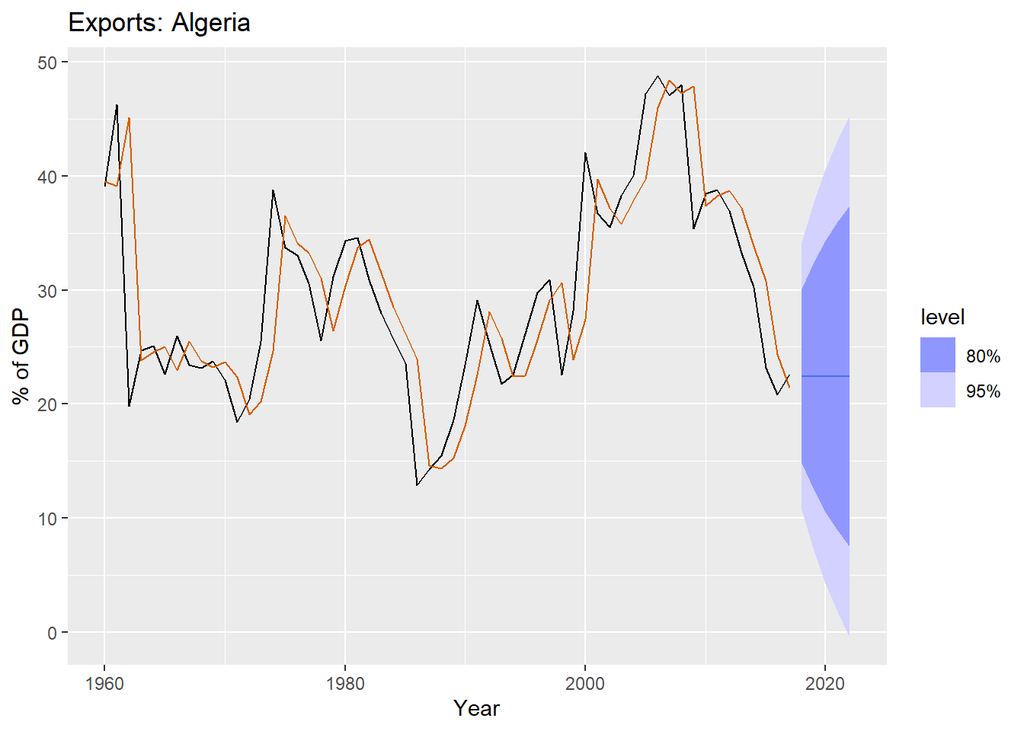

```r
fc |>
  autoplot(algeria_economy) +
  geom_line(aes(y = .fitted), col="#D55E00",
            data = augment(fit)) +
  labs(y="% of GDP", title="Exports: Algeria") +
  guides(colour = "none")
```

Figure 8.2: Simple exponential smoothing applied to exports from Algeria (1960–2017). The orange curve shows the one-step-ahead fitted values.

- 2018–2022년 예측값과 1960–2017년의 one-step-ahead 적합값이 함께 비교됨.
- 큰 평활계수 $\alpha$는 각 시점에서 수준 $\ell_t$가 크게 조정됨을 의미함.
- $\alpha$가 작을수록 변화가 완만해지고, 적합값은 더 부드러워짐.
- 예측구간은 Section 8.7의 방법으로 계산됨.
- 5년 예측 기간 동안 불확실성이 매우 큼을 보여줌.
- 따라서 점예측(point forecast)만으로 해석하면 오해의 소지가 있음.

#### 주의사항

- 점 예측(point forecasts)만을 근거로 해석하는 것은 큰 오해를 초래할 수 있다.
- 예측 구간을 함께 고려하여 미래 예측을 신중하게 해석해야 한다.